# Reproducible example for syg dynamic modeling group

2019-01-09

# Problem

I am trying to model a diffusion-reaction transport process based on a paper by Fu et.al but fail to demonstrate mass is conserved for the system as a test of my implementation.

The paper simulates the release of a small molecule out of the top and bottom faces of a thin cylindrical polymer with no wall transport. Within the polymer cylinder, the molecule can either diffuse or it can react reversibly with a non-diffusing host. The resulting system of ode is solved with the method of lines. Since cylinders are symmetricals the system of equations is simplified to have no release from the bottom face and transport occurs only through the top face.

The modeling is used to simulate the cumulative release process out of the polymer. The paper implements the solution in matlab using ode15s and I would like to translate this approach to R using deSolve. I wanted to ask for your help answering the following questions:

1. Does the code below seems like a reasonable implementation of the model in deSolve?
2. Do you have any ideas why I may be experiencing a lack of mass conservation in the system? Wrong code, wrong implementation or other reason?

Any general suggestions or feedback is always appreciated. Thank you.

# The ode function

```r
affinity <- function(t, state , parms, ...){
# Extracting values passed onto the function through the state argument
  LIGAND <- state[1:N]
  COMPLEX <- state[(N+1):(2*N)]
  RELEASE <- state[2*N+1]
# Initializing the derivatives vectors
  dLIGAND <- rep(0, times = N)
  dCOMPLEX <- rep(0, times = N)
  dRELEASE <- 0

# Method of Lines
Rb           <- p1*LIGAND*(p3 - COMPLEX) - COMPLEX
# Calculating the rate of change of the state variables
dLIGAND[1]   <- p2 * (LIGAND[2] - LIGAND[1])/(delz^2)- Rb[1]
dLIGAND[N-1] <- p2 * (-2*LIGAND[N-1]+LIGAND[N-2])/(delz^2) - Rb[N-1]
for(i in 2:(N-2)){
dLIGAND[i]   <- p2*(LIGAND[i + 1]- 2*LIGAND[i] + LIGAND[i-1])/(delz^2) - Rb[i]}
dCOMPLEX     <- Rb
# dRELEASE <- -(1/2)*p2*(LIGAND[N]-LIGAND[(N-1)])/(delz)
dRELEASE <- -(1/2) * p2 * (-LIGAND[(N-1)]) / (delz)
dudt <- c(dLIGAND, dCOMPLEX, dRELEASE)
ncall <<- ncall+1
return(list(c(dudt)))

  }
```

# The parameters and state variables

```r
# Parameters
N   =    50.0         # Number of boxes
M_l =     0.000426    # Initial drug in gel  in millimoles.
k2  =    36.9         # h^-1
k1  = 11206.53        # h/M
V_h =     0.00785     # mL
K   = k1/(1000*k2)    # mM^-1
C_o = 100*M_l/V_h         # Loading concentration mM
C_T = 0.008810573/V_h # 0.1178505 mM
C_c = 0.000001*C_T        # Free cyclodextrin pockets
L_eq = ((C_o) / (1 + K * C_c))               # Ligand Equilibrium
complex_eq = (C_o - ((C_o) / (1 + K * C_c))) #
delz = 1/N # dimensionless
# Dimensionless parameters
p1 = k1 * C_o / k2
p2 = 0.933       # From Paper
p3 = C_T/C_o
LIGAND <- rep(L_eq/(C_o*(N-1)), times = N)
LIGAND[N] <- 0
COMPLEX <- rep(complex_eq/(C_o*N), times = N)
RELEASE <- 0
state <- c(LIGAND = LIGAND,
           COMPLEX = COMPLEX,
           RELEASE = RELEASE)
```

# Solving the equation

```r
library(deSolve)
ncall <- 0
times <- seq(0, 350*k2, by = 1)
out <- ode(func = affinity,
           times = times,
           y = state)
```

# Plotting

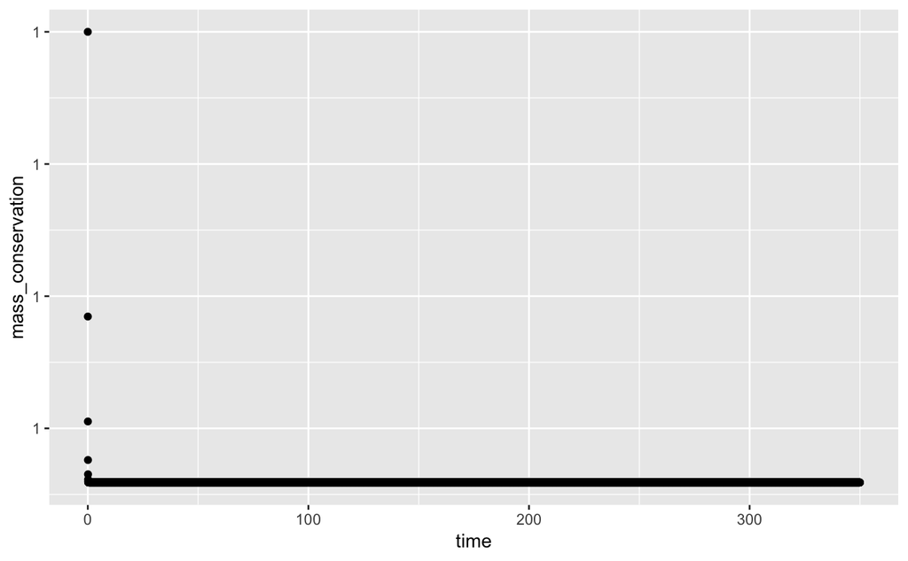

```r
library(tidyverse)
# Turning the desolve object to a tidy dataframe
tidy_out <- as.data.frame(out) %>%
  select(-RELEASE) %>%
  gather(., key = "species", value = "concentration", -time) %>%
  separate(col = species,
           into = c("species", "z"),
           sep = "(?<=[:alpha:])(?=[:digit:])") %>%
  mutate(z = as.numeric(z)) %>%
  mutate(time = time/k2) # time in hrs
# Grabbing the Release variable. I expect it to go up to 1
tidy_release_media <- out %>%
  as.data.frame() %>%
  select(time, RELEASE) %>%
  mutate(time = time / k2)

# Grouping by time both the ligand and the complex to get a sum of all drug
# within the polymer through time. I expect this to go down
tidy_release_polymer <- tidy_out %>%
  filter(species %in% c("LIGAND", "COMPLEX")) %>%
  group_by(time) %>%
  summarise(concentration = sum(concentration))
# When I sum both the drug escaping the polymer and the drug entering the solution
# I expect it to be a flat line around 1 (+/- numerical error) due to the principle
# of mass conservation
tidy_release_polymer %>%
  inner_join(tidy_release_media, by = "time") %>%
  rename(release_polymer = concentration,
         release_media = RELEASE) %>%
  mutate(mass_conservation = release_polymer + 100*release_media) %>%
  ggplot(aes(x = time, y = mass_conservation))+
  geom_point()
```